# SDS 3386

Assignment 2

Thinh Hong

2019-09-24 23:00:14

```r
# load libraries
library(dplyr)
library(readxl)
library(janitor)
library(ggplot2)
library(skimr)
library(stringr)
library(plyr)
```

# Description

By studying the data in the statementofvotescastoctober242018.xls,it is being deterrmined if the winner beat the 2nd place person in all polls(precint).

# Headline

The following plot is the comparision between the first place winner and the second place winner. It shows the differnece in votes for every presinct.

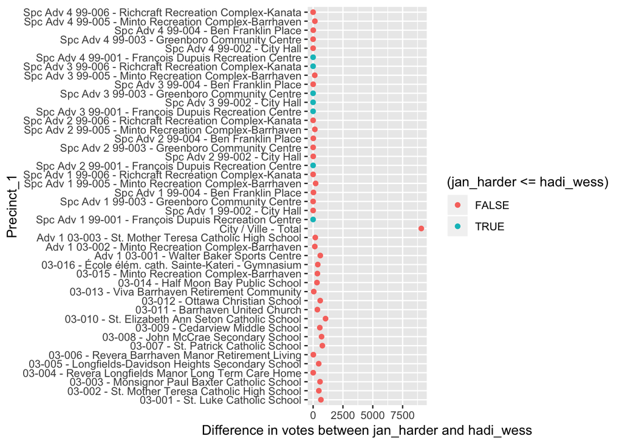

```r
dataset <- read_excel("statementofvotescastoctober242018.xls", sheet = "Ward 3",skip = 2)
dataset <- dataset %>% clean_names() %>% select("precinct_1","jan_harder","hadi_wess") %>% na.omit(dataset)

dataset %>% ggplot(aes(x = precinct_1 ,y =jan_harder - hadi_wess , colour = (jan_harder <= hadi_wess)))+
geom_point()+
coord_flip()+
labs(
x = 'Precinct_1',
y = 'Difference in votes between jan_harder and hadi_wess'
)
```

In this plot, the first place winner amount of votes is compared to the second place winner in every presinct. Here we can see in this is plot that jan harder, the first place winner has either tied Hadi Wess or gotten fewer votes several times. Showing that jan harder has not beaten Hadi in every precinct . If we remove the presincts that had 0 votes for both people, there is still 1 presinct that they tied in. Jan harder has not beaten Hadi Wess everytime.

# Comments

In order for Jan to be considered winning in terms of votes, Jan must not have the same amount of of fewer votes than Hadi. The results do make sense because although Jan did win by a lot of total votes, different areas may disagree on people to vote for. We are assuming this data is accurate. All districts do matter.

# Suggestions for further explorations

-Ensure all presincts votes were counted properly and fairy will help the results be more accurate.

# PART 2

#Description We are using a binomial test to see if the coin toss is fair

# Headline

The following binomial test is comparing all the coin tosses and seeing if the coin toss is fair. The results of the coin toss are given. The null hypothesis is assuming that the coin toss is fair and there is no true difference in the means between head and tails. The alternate hypothesis states that the coin toss is not fair and there is a true difference in means between heads and tails.

```r
x <- c("t", "t", "h", "t", "h", "h", "t", "t", "t", "t", "t", "t", "h", "h", "t", "h", "t", "t", "t", "t", "t", "h", "t", "t", "h", "t")

hs = str_count(x,"h")
ts = str_count(x,"t")
heads <- sum(hs,1)
tails <- sum(ts,1)

binom.test(8,26,p=0.5,alternative=c("two.sided"),conf.level=0.95)
```

```
##
##  Exact binomial test
##
## data:  8 and 26
## number of successes = 8, number of trials = 26, p-value = 0.07552
## alternative hypothesis: true probability of success is not equal to 0.5
## 95 percent confidence interval:
##  0.1432600 0.5178964
## sample estimates:
## probability of success
##              0.3076923
```

#Comments

# Suggestions for further explorations

In order to have a higher chance of correctly assuming the coin toss is fair, doing more trials will have bring the probability to where it should be.

# References

No sources were used